# ANLY535_Machine learning II_Project_Final_code (1)

## Model using Tensorflow framework

#### Modeling in tensorflow using greyscale images

```python
import os
import time
from __future__ import absolute_import
from __future__ import print_function
from datetime import timedelta
import h5py
import numpy as np
import tensorflow as tf
import matplotlib.pyplot as plt
import seaborn as sns

%matplotlib inline
plt.rcParams['figure.figsize'] = (16.0, 4.0) # Set default figure size
```

[output not shown]

```python
TENSORBOARD_SUMMARIES_DIR = '/tmp/svhn_classifier_logs'
```

#### Loading data

```python
# Open the file as readonly
h5f = h5py.File('SVHN_grey.h5', 'r')

# Load the training, test and validation set
X_train = h5f['X_train'][:]
y_train = h5f['y_train'][:]
X_test = h5f['X_test'][:]
y_test = h5f['y_test'][:]
X_val = h5f['X_val'][:]
y_val = h5f['y_val'][:]

# Close this file
h5f.close()

print('Training set', X_train.shape, y_train.shape)
print('Validation set', X_val.shape, y_val.shape)
print('Test set', X_test.shape, y_test.shape)
```

```
Training set (63733, 32, 32, 1) (63733, 10)
Validation set (9524, 32, 32, 1) (9524, 10)
Test set (26032, 32, 32, 1) (26032, 10)
```

#### Helper function for plotting the results when we are predicting the labels It randomly selects the images . This plots the nrows and mcols.

```python
def plot_images(images, nrows, ncols, cls_true, cls_pred=None):
    """ Create figure with nrows and ncols
    """
    # Initializing the subplots
    fig, axes = plt.subplots(nrows, ncols)

    # Randomly selecting nrows * ncols images
    rs = np.random.choice(images.shape[0], nrows*ncols)


    for i, ax in zip(rs, axes.flat):

        # If the predictions are not passed
        if cls_pred is None:
            title = "True: {0}".format(np.argmax(cls_true[i]))

        # When predictions are passed, this displays the prediction and labels in images
        else:
            title = "True: {0}, Pred: {1}".format(np.argmax(cls_true[i]), cls_pred[i])

        # Displays the image
        ax.imshow(images[i,:,:,0], cmap='binary')

        # Image annotating
        ax.set_title(title)

        # Setting for not overlaying the grid
        ax.set_xticks([])
        ax.set_yticks([])
```

#### This clears the log file and creates new directories.

```python
def prepare_log_dir():
    if tf.gfile.Exists(TENSORBOARD_SUMMARIES_DIR):
        tf.gfile.DeleteRecursively(TENSORBOARD_SUMMARIES_DIR)
    tf.gfile.MakeDirs(TENSORBOARD_SUMMARIES_DIR)
```

#### The batch size is defined which the subset size of the training sample and used to train the network.

```python
def get_batch(X, y, batch_size=512):
    for i in np.arange(0, y.shape[0], batch_size):
        end = min(X.shape[0], i + batch_size)
        yield(X[i:end],y[i:end])
```

#### Placeholder variable where the both are of type float. The tf.logging.set_verbosity(tf.logging.INFO) will tell all the messages that have the label INFO.y_clf which defines the new tensor as the argmax of y.

```python
comp1 = 32*32
tf.logging.set_verbosity(tf.logging.INFO)

# Our application logic will be added here
x = tf.placeholder(tf.float32, shape = [None, 32, 32, 1], name='Input_Data')
y = tf.placeholder(tf.float32, shape = [None, 10], name='Input_Labels')
y_cls = tf.argmax(y, 1)

discard_rate = tf.placeholder(tf.float32, name='Discard_rate')
os.environ['TF_CPP_MIN_LOG_LEVEL']='2'
```

#### Convolutional neural network architecture function.The first input layer is defined. There are two convolutional layers, two relu. The next layer has dropout and finally there is fully connected layer and relu. We have used strides which is 2 and applied relu function to remove elements which are negative

[output not shown]

[output not shown]

```python
max_epochs = 2
numexamples = X_train.shape[0]
```

```python
prepare_log_dir()
```

#### Prediction and optimizer: The loss is calculated for each iteration using prediction from cnn_model_fn(). The optimizer used is Adam Optimizer.

```python
#with tf.name_scope('Model Prediction'):
prediction = cnn_model_fn(x)
prediction_cls = tf.argmax(prediction, 1)
#with tf.name_scope('loss'):
loss = tf.reduce_mean(tf.losses.softmax_cross_entropy(
   onehot_labels=y, logits=prediction))
    #tf.summary.scalar('loss', loss)

#with tf.name_scope('Adam Optimizer'):
optimizer = tf.train.AdamOptimizer().minimize(loss)
```

[output not shown]

#### Accuracy : The below checks the maximum value of the predicted image.

```python
#Here you check whether the index of the maximum value of the predicted image is equal to the actual labelled image. and both will be a column vector.
correct_prediction = tf.equal(prediction_cls, y_cls)
#calculate accuracy across all the given images and average them out.
accuracy = tf.reduce_mean(tf.cast(correct_prediction, tf.float32))
```

## Tensorflow session

#### Initializing the session

```python
sess = tf.Session()
```

```python
sess.run(tf.global_variables_initializer())
```

```python
saver = tf.train.Saver()

save_dir = 'checkpnts/'

# Create directory if it does not exist
if not os.path.exists(save_dir):
    os.makedirs(save_dir)

save_path = os.path.join(save_dir, 'svhn_greyscale')
```

```python
#saver.restore(sess=session, save_path=save_path)
```

```python
## No of example in each batch for updating weights
batch_size = 512

#Discarding or fuse % of neurons in Train mode
discard_per = 0.7
```

```python
def evaluate_batch(test, batch_size):
    """ Evaluate in batches
    """
    # Store the cumulative accuracy over all batches
    cumulative_accuracy = 0.0

    # Get the number of images
    n_images = y_test.shape[0] if test else y_val.shape[0]

    # Numer of batches needed to evaluate all images
    n_batches = n_images // batch_size + 1

    # Iterate over all the batches
    for i in range(n_batches):

        # Calculate the offset
        offset = i * batch_size

        if test:
            # Get the batch from the test set
            xs, ys = X_test[offset:offset+batch_size], y_test[offset:offset+batch_size]
        else:
            # Get batch from the validation set
            xs, ys = X_val[offset:offset+batch_size], y_val[offset:offset+batch_size]

        cumulative_accuracy += sess.run(accuracy,
                {x: xs, y: ys})

    # Return the average accuracy over all batches
    return cumulative_accuracy / float(n_batches)
```

```python
#with tf.Session() as sess:
 #   sess.run(tf.global_variables_initializer())

## To calculate total time of training

train_loss = []
valid_loss = []
start_time = time.time()
for epoch in range(20):
    print ('Training .........')
    epoch_loss = 0
    print ()
    print ('Epoch ', epoch+1 , ': ........ \n')
    step = 0

    ## Training epochs ....
    for (epoch_x , epoch_y) in get_batch(X_train, y_train, batch_size):
        _, train_accu, c = sess.run([optimizer, accuracy, loss], feed_dict={x: epoch_x, y: epoch_y, discard_rate: discard_per})
        train_loss.append(c)

        if(step%40 == 0):
            print ("Step:", step, ".....", "\nMini-Batch Loss   : ", c)
            print('Mini-Batch Accuracy :' , train_accu*100.0, '%')

            ## Validating prediction and summaries
            accu = 0.0
            for (epoch_x , epoch_y) in get_batch(X_val, y_val, 512):
                correct, _c = sess.run([correct_prediction, loss], feed_dict={x: epoch_x, y: epoch_y, discard_rate: 0.0})
                valid_loss.append(_c)
                accu+= np.sum(correct[correct == True])
            print('Validation Accuracy :' , accu*100.0/y_val.shape[0], '%')
            print ()
        step = step + 1


    print ('Epoch', epoch+1, 'completed out of ', max_epochs)
    # Calculate and display the testset accuracy
test_acc = evaluate_batch(test=True, batch_size=batch_size)
print("Test accuracy: %.4f" % test_acc)

## Calculate net time
time_diff = time.time() - start_time

## Testing prediction and summaries
accu = 0.0
for (epoch_x , epoch_y) in get_batch(X_test, y_test, 512):
    correct = sess.run([correct_prediction], feed_dict={x: epoch_x, y: epoch_y, discard_rate: 0.0})
    accu+= np.sum(correct[correct == True])
print('Test Accuracy :' , accu*100.0/y_test.shape[0], '%')
print("Time usage: " + str(timedelta(seconds=int(round(time_diff)))))

print("Final test accuracy: %.4f" % test_acc)
```

```
Training .........

Epoch  1 : ........

Step: 0 .....
Mini-Batch Loss   :  2.3163805
Mini-Batch Accuracy : 11.71875 %
Validation Accuracy : 18.92062158756825 %

Step: 40 .....
Mini-Batch Loss   :  1.7520211
Mini-Batch Accuracy : 43.9453125 %
Validation Accuracy : 47.59554808903822 %

Step: 80 .....
Mini-Batch Loss   :  0.7285069
Mini-Batch Accuracy : 78.7109375 %
Validation Accuracy : 77.93994120117598 %

Step: 120 .....
Mini-Batch Loss   :  0.5915649
Mini-Batch Accuracy : 83.3984375 %
Validation Accuracy : 81.94036119277614 %

Epoch 1 completed out of  2
Training .........

Epoch  2 : ........

Step: 0 .....
Mini-Batch Loss   :  0.54695493
Mini-Batch Accuracy : 83.984375 %
Validation Accuracy : 82.53884922301555 %

Step: 40 .....
Mini-Batch Loss   :  0.6104192
Mini-Batch Accuracy : 83.984375 %
Validation Accuracy : 83.60982780344393 %

Step: 80 .....
```

[output cut: 449 more lines]

```
Step: 80 .....
Mini-Batch Loss   :  0.037780836
Mini-Batch Accuracy : 98.828125 %
Validation Accuracy : 88.6077278454431 %

Step: 120 .....
Mini-Batch Loss   :  0.059812408
Mini-Batch Accuracy : 98.6328125 %
Validation Accuracy : 88.90172196556068 %

Epoch 20 completed out of  2
Test accuracy: 0.8721
Test Accuracy : 87.20421020282728 %
Time usage: 0:00:57
Final test accuracy: 0.8721
```

```python
accu = 0.0
for (epoch_x , epoch_y) in get_batch(X_test, y_test, 512):
    correct = sess.run([correct_prediction], feed_dict={x: epoch_x, y: epoch_y, discard_rate: 0.0})
    predcls, classy = sess.run([prediction_cls, y_cls], feed_dict={x: epoch_x, y: epoch_y, discard_rate: 0.0})
    accumulate = np.sum((predcls == classy)*1)
    crct = np.sum(correct[correct == True])
    deaccumulate = np.sum((predcls != classy)*1)
    accu+= accumulate
    print('Test Accuracy :' , accumulate, crct, deaccumulate, accumulate+ deaccumulate, y_test.shape[0], '%')
print ()
```

```
Test Accuracy : 438 438 74 512 26032 %
Test Accuracy : 443 443 69 512 26032 %
Test Accuracy : 444 444 68 512 26032 %
Test Accuracy : 425 425 87 512 26032 %
Test Accuracy : 462 462 50 512 26032 %
Test Accuracy : 450 450 62 512 26032 %
Test Accuracy : 458 458 54 512 26032 %
Test Accuracy : 443 443 69 512 26032 %
Test Accuracy : 439 439 73 512 26032 %
Test Accuracy : 445 445 67 512 26032 %
Test Accuracy : 453 453 59 512 26032 %
Test Accuracy : 439 439 73 512 26032 %
Test Accuracy : 447 447 65 512 26032 %
Test Accuracy : 453 453 59 512 26032 %
Test Accuracy : 441 441 71 512 26032 %
Test Accuracy : 449 449 63 512 26032 %
Test Accuracy : 451 451 61 512 26032 %
Test Accuracy : 447 447 65 512 26032 %
Test Accuracy : 444 444 68 512 26032 %
Test Accuracy : 445 445 67 512 26032 %
Test Accuracy : 440 440 72 512 26032 %
Test Accuracy : 463 463 49 512 26032 %
Test Accuracy : 445 445 67 512 26032 %
Test Accuracy : 454 454 58 512 26032 %
Test Accuracy : 453 453 59 512 26032 %
Test Accuracy : 430 430 82 512 26032 %
Test Accuracy : 465 465 47 512 26032 %
Test Accuracy : 444 444 68 512 26032 %
Test Accuracy : 451 451 61 512 26032 %
Test Accuracy : 439 439 73 512 26032 %
Test Accuracy : 433 433 79 512 26032 %
Test Accuracy : 457 457 55 512 26032 %
Test Accuracy : 457 457 55 512 26032 %
Test Accuracy : 435 435 77 512 26032 %
Test Accuracy : 450 450 62 512 26032 %
Test Accuracy : 446 446 66 512 26032 %
Test Accuracy : 451 451 61 512 26032 %
Test Accuracy : 434 434 78 512 26032 %
Test Accuracy : 450 450 62 512 26032 %
Test Accuracy : 444 444 68 512 26032 %
Test Accuracy : 453 453 59 512 26032 %
Test Accuracy : 448 448 64 512 26032 %
Test Accuracy : 450 450 62 512 26032 %
Test Accuracy : 443 443 69 512 26032 %
Test Accuracy : 446 446 66 512 26032 %
Test Accuracy : 437 437 75 512 26032 %
Test Accuracy : 440 440 72 512 26032 %
Test Accuracy : 454 454 58 512 26032 %
Test Accuracy : 444 444 68 512 26032 %
Test Accuracy : 443 443 69 512 26032 %
Test Accuracy : 386 386 46 432 26032 %
```

```python
saver.save(sess=sess, save_path=save_path)
```

```
'checkpnts/svhn_greyscale'
```

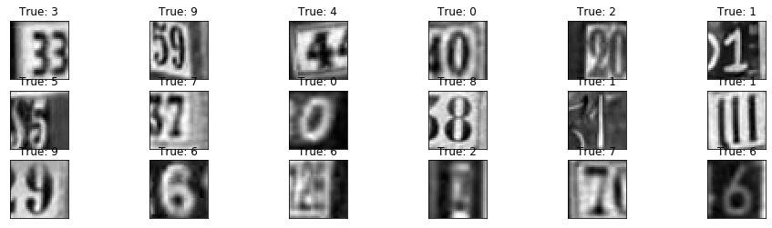

```python
plot_images(X_train, 3, 6, y_train);
```

```python
testpred = []
for (epoch_x , epoch_y) in get_batch(X_test, y_test, 512):
    correct = sess.run([prediction_cls], feed_dict={x: epoch_x, y: epoch_y, discard_rate: 0.0})
for (epoch_x , epoch_y) in get_batch(X_test, y_test, 512):
    correct = sess.run([prediction_cls], feed_dict={x: epoch_x, y: epoch_y, discard_rate: 0.0})
    testpred.append((np.asarray(correct, dtype=int)).T)
print ('Completed')
```

```
Completed
```

```python
def flatten(lists):
    results = []
    for numbers in lists:
        for x in numbers:
            results.append(x)
    return np.asarray(results)
```

```python
flat_array = flatten(testpred)
flat_array = (flat_array.T)
flat_array = flat_array[0]
```

```python
flat_array.shape
```

```
(26032,)
```

```python
# Feed the test set with dropout disabled
test_feed_dict={
    x: X_test,
    y: y_test,

}

# Generate predictions for the testset
testpred = sess.run(y_cls, feed_dict=test_feed_dict)

# Display the predictions
testpred
```

```
array([5, 2, 1, ..., 7, 6, 7])
```

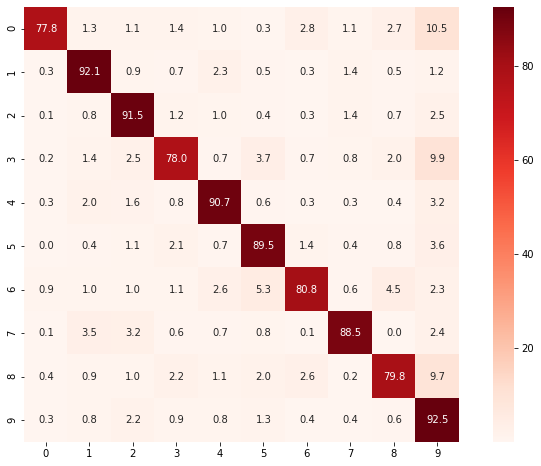

```python
from sklearn.metrics import confusion_matrix
# Set the figure size
plt.figure(figsize=(12, 8))

# Calculate the confusion matrix
cm = confusion_matrix(y_true=np.argmax(y_test, axis=1), y_pred=flat_array)

# Normalize the confusion matrix
cm = cm.astype('float') / cm.sum(axis=1)[:, np.newaxis] * 100.0

# Visualize the confusion matrix
sns.heatmap(cm, annot=True, cmap='Reds', fmt='.1f', square=True);
```

##### Analyzing incorrectly and correctly classified images

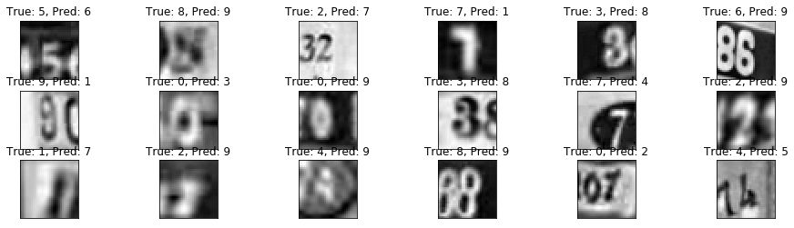

```python
incorrect = flat_array != np.argmax(y_test, axis=1)

images = X_test[incorrect]
cls_true = y_test[incorrect]
cls_pred = flat_array[incorrect]

plot_images(images, 3, 6, cls_true, cls_pred);
```

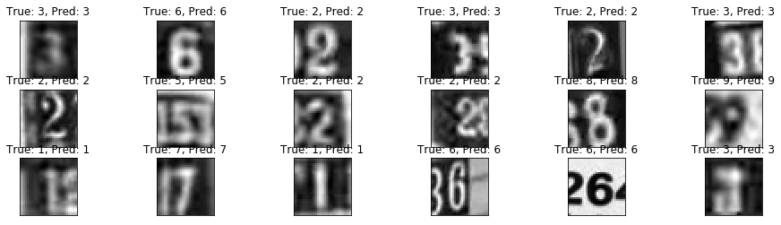

```python
correct = np.invert(incorrect)
images = X_test[correct]
cls_true = y_test[correct]
cls_pred = flat_array[correct]

plot_images(images, 3, 6, cls_true, cls_pred);
```

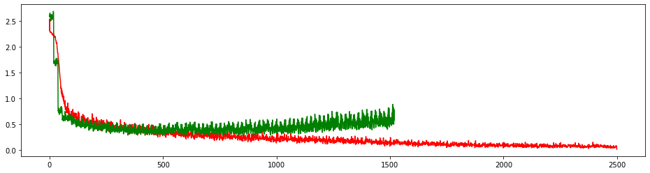

```python
import matplotlib.pyplot as plt
plt.plot(train_loss ,'r',label = "Train_loss")
plt.plot(valid_loss, 'g',label = "Valid_loss")
```

#### Tensorflow on non grayscale images

```python
# Ignore warnings :
import warnings
warnings.filterwarnings('ignore')

import os
import sys
import numpy as np
import pandas as pd
import matplotlib.pyplot as plt
import seaborn as sns
from PIL import Image, ImageDraw
from IPython.display import display, Image, HTML
from scipy.io import loadmat
from skimage import color
from skimage import io
from sklearn.model_selection import train_test_split
import json
import h5py
from scipy.io import loadmat
import cv2

%matplotlib inline
plt.rcParams['figure.figsize'] = (16.0, 4.0)
```

```python
# X are the pixels of the images and y are the corresponding labels.
def load_data(path):
    """ Helper function for loading a MAT-File"""
    data = loadmat(path)
    return data['X'], data['y']

X_train, y_train = load_data('train_32x32.mat')
X_test, y_test = load_data('test_32x32.mat')

print("Training Set", X_train.shape, y_train.shape)
print("Test Set", X_test.shape, y_test.shape)
```

```
Training Set (32, 32, 3, 73257) (73257, 1)
Test Set (32, 32, 3, 26032) (26032, 1)
```

```python
# Transpose the image arrays, we are transforming the input data so that each instance of
#data represents pixels values of each image in all of three channels(RGB)

X_train, y_train = X_train.transpose((3,0,1,2)), y_train[:,0]
X_test, y_test = X_test.transpose((3,0,1,2)), y_test[:,0]

print("Training Set", X_train.shape)
print("Test Set", X_test.shape)
print('')

# Calculate the total number of images
num_images = X_train.shape[0] + X_test.shape[0]

print("Total Number of Images", num_images)
```

```
Training Set (73257, 32, 32, 3)
Test Set (26032, 32, 32, 3)

Total Number of Images 99289
```

```python
#Converting Label 10 -> 0
y_train[y_train == 10] = 0
y_test[y_test == 10] = 0
```

```python
# Splitting to 13% in Val Set
X_train, X_val, y_train, y_val = train_test_split(X_train, y_train, test_size=0.13, random_state=7, stratify = y_train)
```

```python
# Calculate the mean on the training data
train_mean = np.mean(X_train, axis=0)

# Calculate the std on the training data
train_std = np.std(X_train, axis=0)

# Subtract it equally from all splits
train_norm = (X_train - train_mean) / train_std
test_norm = (X_test - train_mean)  / train_std
val_norm = (X_val - train_mean) / train_std
```

```python
def plot_images(img, labels, nrows, ncols):
    """ Plot nrows x ncols images
    """
    fig, axes = plt.subplots(nrows, ncols)
    for i, ax in enumerate(axes.flat):
        if img[i].shape == (32, 32, 3):
            ax.imshow(img[i])
        else:
            ax.imshow(img[i,:,:,0])
        ax.set_xticks([]); ax.set_yticks([])
        ax.set_title(labels[i])
```

```
Clipping input data to the valid range for imshow with RGB data ([0..1] for floats or [0..255] for integers).
Clipping input data to the valid range for imshow with RGB data ([0..1] for floats or [0..255] for integers).
Clipping input data to the valid range for imshow with RGB data ([0..1] for floats or [0..255] for integers).
Clipping input data to the valid range for imshow with RGB data ([0..1] for floats or [0..255] for integers).
```

[figure not shown]

```python
plot_images(train_norm, y_train, 1, 4)
```

```python
from sklearn.preprocessing import OneHotEncoder

# Fit the OneHotEncoder
enc = OneHotEncoder().fit(y_train.reshape(-1, 1))

# Transform the label values to a one-hot-encoding scheme
y_train = enc.transform(y_train.reshape(-1, 1)).toarray()
y_test = enc.transform(y_test.reshape(-1, 1)).toarray()
y_val = enc.transform(y_val.reshape(-1, 1)).toarray()

print("Training set", y_train.shape)
print("Validation set", y_val.shape)
print("Test set", y_test.shape)
```

```
Training set (63733, 10)
Validation set (9524, 10)
Test set (26032, 10)
```

```python
import h5py

# Create file
h5f1 = h5py.File('SVHN_grey.h51', 'w')
#h5f1Store the datasets
h5f1.create_dataset('X_train', data=train_norm)
h5f1.create_dataset('y_train', data=y_train)
h5f1.create_dataset('X_test', data=test_norm)
h5f1.create_dataset('y_test', data=y_test)
h5f1.create_dataset('X_val', data=val_norm)
h5f1.create_dataset('y_val', data=y_val)

# Close the file
h5f1.close()
```

```python
import os
import time
from __future__ import absolute_import
from __future__ import print_function
from datetime import timedelta
import h5py
import numpy as np
import tensorflow as tf
import matplotlib.pyplot as plt
import seaborn as sns

%matplotlib inline
plt.rcParams['figure.figsize'] = (16.0, 4.0) # Set default figure size
```

```python
# Open the file as readonly
h5f1 = h5py.File('SVHN_grey.h51', 'r')

# Load the training, test and validation set
X_train = h5f1['X_train'][:]
y_train = h5f1['y_train'][:]
X_test = h5f1['X_test'][:]
y_test = h5f1['y_test'][:]
X_val = h5f1['X_val'][:]
y_val = h5f1['y_val'][:]

# Close this file
h5f1.close()

print('Training set', X_train.shape, y_train.shape)
print('Validation set', X_val.shape, y_val.shape)
print('Test set', X_test.shape, y_test.shape)
```

```
Training set (63733, 32, 32, 3) (63733, 10)
Validation set (9524, 32, 32, 3) (9524, 10)
Test set (26032, 32, 32, 3) (26032, 10)
```

```python
def plot_images(images, nrows, ncols, cls_true, cls_pred=None):
    """ Create figure with nrows and ncols
    """
    # Initializing the subplots
    fig, axes = plt.subplots(nrows, ncols)

    # Randomly selecting nrows * ncols images
    rs = np.random.choice(images.shape[0], nrows*ncols)


    for i, ax in zip(rs, axes.flat):

        # If the predictions are not passed
        if cls_pred is None:
            title = "True: {0}".format(np.argmax(cls_true[i]))

        # When predictions are passed, this displays the prediction and labels in images
        else:
            title = "True: {0}, Pred: {1}".format(np.argmax(cls_true[i]), cls_pred[i])

        # Displays the image
        ax.imshow(images[i,:,:,0], cmap='binary')

        # Image annotating
        ax.set_title(title)

        # Setting for not overlaying the grid
        ax.set_xticks([])
        ax.set_yticks([])
```

```python
def prepare_log_dir():
    if tf.gfile.Exists(TENSORBOARD_SUMMARIES_DIR):
        tf.gfile.DeleteRecursively(TENSORBOARD_SUMMARIES_DIR)
    tf.gfile.MakeDirs(TENSORBOARD_SUMMARIES_DIR)
```

```python
def get_batch(X, y, batch_size=512):
    for i in np.arange(0, y.shape[0], batch_size):
        end = min(X.shape[0], i + batch_size)
        yield(X[i:end],y[i:end])
```

```python
comp = 32*32
tf.logging.set_verbosity(tf.logging.INFO)

# Our application logic will be added here
x = tf.placeholder(tf.float32, shape = [None, 32, 32, 3], name='Input_Data')
y = tf.placeholder(tf.float32, shape = [None, 10], name='Input_Labels')
y_cls = tf.argmax(y, 1)

discard_rate = tf.placeholder(tf.float32, name='Discard_rate')
os.environ['TF_CPP_MIN_LOG_LEVEL']='2'
```

```python
def cnn_model_fn(features):
    """Model function for CNN."""

      # Input Layer
    input_layer = tf.reshape(features, [-1, 32, 32, 3], name='Reshaped_Input')

      # Convolutional Layer #1
    #with tf.name_scope('Conv1 Layer + ReLU'):

    conv1 = tf.layers.conv2d(
        inputs=input_layer,
        filters=32,
        kernel_size=[5, 5],
        padding="same",
        activation=tf.nn.relu)

      # Pooling Layer with 2x2 matrix by 2 cells and stride 2
    pool1 = tf.layers.max_pooling2d(inputs=conv1, pool_size=[2, 2], strides=2)

      # Convolutional Layer #2 and Pooling Layer #2
    conv2 = tf.layers.conv2d(
          inputs=pool1,
          filters=64,
          kernel_size=[5, 5],
          padding="same",
          activation=tf.nn.relu)

   ## Pooling Layer with 2x2 matrix by 2 cells and stride 2
    pool2 = tf.layers.max_pooling2d(inputs=conv2, pool_size=[2, 2], strides=2)

      # Dense and dropout layer
    pool2_flat = tf.reshape(pool2, [-1, 8 * 8 * 64])
    dense = tf.layers.dense(inputs=pool2_flat, units=256, activation=tf.nn.relu)
    dropout = tf.layers.dropout(
         inputs=dense, rate=discard_rate)

      # Logits Layer
    logits = tf.layers.dense(inputs=dropout, units=10)

    return logits
```

```python
max_epochs = 2
num_examples = X_train.shape[0]
```

```python
TENSORBOARD_SUMMARIES_DIR = '/tmp/svhn_classifier_logs'
prepare_log_dir()
```

```python
#with tf.name_scope('Model Prediction'):
prediction = cnn_model_fn(x)
prediction_cls = tf.argmax(prediction, 1)
#with tf.name_scope('loss'):
loss = tf.reduce_mean(tf.losses.softmax_cross_entropy(
   onehot_labels=y, logits=prediction))
    #tf.summary.scalar('loss', loss)

#with tf.name_scope('Adam Optimizer'):
optimizer = tf.train.AdamOptimizer().minimize(loss)
```

```python
#Here you check whether the index of the maximum value of the predicted image is equal to the actual labelled image. and both will be a column vector.
correct_prediction = tf.equal(prediction_cls, y_cls)
#calculate accuracy across all the given images and average them out.
accuracy = tf.reduce_mean(tf.cast(correct_prediction, tf.float32))
```

```python
sess = tf.Session()
```

```python
sess.run(tf.global_variables_initializer())
```

```python
saver = tf.train.Saver()

save_dir = 'checkpnts/'

# Create directory if it does not exist
if not os.path.exists(save_dir):
    os.makedirs(save_dir)

save_path = os.path.join(save_dir, 'svhn_single_greyscale')
```

```python
## No of example in each batch for updating weights
batch_size = 512

#Discarding or fuse % of neurons in Train mode
discard_per = 0.7
```

```python
def evaluate_batch(test, batch_size):
    """ Evaluate in batches
    """
    # Store the cumulative accuracy over all batches
    cumulative_accuracy = 0.0

    # Get the number of images
    n_images = y_test.shape[0] if test else y_val.shape[0]

    # Numer of batches needed to evaluate all images
    n_batches = n_images // batch_size + 1

    # Iterate over all the batches
    for i in range(n_batches):

        # Calculate the offset
        offset = i * batch_size

        if test:
            # Get the batch from the test set
            xs, ys = X_test[offset:offset+batch_size], y_test[offset:offset+batch_size]
        else:
            # Get batch from the validation set
            xs, ys = X_val[offset:offset+batch_size], y_val[offset:offset+batch_size]

        cumulative_accuracy += sess.run(accuracy,
                {x: xs, y: ys})

    # Return the average accuracy over all batches
    return cumulative_accuracy / float(n_batches)
```

```python
#with tf.Session() as sess:
 #   sess.run(tf.global_variables_initializer())

## To calculate total time of training

train_loss = []
valid_loss = []
start_time = time.time()
for epoch in range(20):
    print ('Training .........')
    epoch_loss = 0
    print ()
    print ('Epoch ', epoch+1 , ': ........ \n')
    step = 0

    ## Training epochs ....
    for (epoch_x , epoch_y) in get_batch(X_train, y_train, batch_size):
        _, train_accu, c = sess.run([optimizer, accuracy, loss], feed_dict={x: epoch_x, y: epoch_y, discard_rate: discard_per})
        train_loss.append(c)

        if(step%40 == 0):
            print ("Step:", step, ".....", "\nMini-Batch Loss   : ", c)
            print('Mini-Batch Accuracy :' , train_accu*100.0, '%')

            ## Validating prediction and summaries
            accu = 0.0
            for (epoch_x , epoch_y) in get_batch(X_val, y_val, 512):
                correct, _c = sess.run([correct_prediction, loss], feed_dict={x: epoch_x, y: epoch_y, discard_rate: 0.0})
                valid_loss.append(_c)
                accu+= np.sum(correct[correct == True])
            print('Validation Accuracy :' , accu*100.0/y_val.shape[0], '%')
            print ()
        step = step + 1


    print ('Epoch', epoch+1, 'completed out of ', max_epochs)
    # Calculate and display the testset accuracy
test_acc = evaluate_batch(test=True, batch_size=batch_size)
print("Test accuracy: %.4f" % test_acc)

## Calculate net time
time_diff = time.time() - start_time

## Testing prediction and summaries
accu = 0.0
for (epoch_x , epoch_y) in get_batch(X_test, y_test, 512):
    correct = sess.run([correct_prediction], feed_dict={x: epoch_x, y: epoch_y, discard_rate: 0.0})
    accu+= np.sum(correct[correct == True])
print('Test Accuracy :' , accu*100.0/y_test.shape[0], '%')
print("Time usage: " + str(timedelta(seconds=int(round(time_diff)))))

print("Final test accuracy: %.4f" % test_acc)
```

```
Training .........

Epoch  1 : ........

Step: 0 .....
Mini-Batch Loss   :  2.3732564
Mini-Batch Accuracy : 8.203125 %
Validation Accuracy : 18.92062158756825 %

Step: 40 .....
Mini-Batch Loss   :  1.9276531
Mini-Batch Accuracy : 32.03125 %
Validation Accuracy : 38.70222595548089 %

Step: 80 .....
Mini-Batch Loss   :  0.77309257
Mini-Batch Accuracy : 77.5390625 %
Validation Accuracy : 71.96556068878623 %

Step: 120 .....
Mini-Batch Loss   :  0.6519426
Mini-Batch Accuracy : 81.25 %
Validation Accuracy : 81.41537169256615 %

Epoch 1 completed out of  2
Training .........

Epoch  2 : ........

Step: 0 .....
Mini-Batch Loss   :  0.59631556
Mini-Batch Accuracy : 82.6171875 %
Validation Accuracy : 81.02687946241075 %

Step: 40 .....
Mini-Batch Loss   :  0.60961086
Mini-Batch Accuracy : 83.3984375 %
Validation Accuracy : 82.95884082318354 %

Step: 80 .....
```

[output cut: 449 more lines]

```
Step: 80 .....
Mini-Batch Loss   :  0.061865248
Mini-Batch Accuracy : 98.2421875 %
Validation Accuracy : 87.7257454850903 %

Step: 120 .....
Mini-Batch Loss   :  0.04831108
Mini-Batch Accuracy : 98.6328125 %
Validation Accuracy : 88.5657286854263 %

Epoch 20 completed out of  2
Test accuracy: 0.8725
Test Accuracy : 87.23494161032575 %
Time usage: 0:01:06
Final test accuracy: 0.8725
```

```python
accu = 0.0
for (epoch_x , epoch_y) in get_batch(X_test, y_test, 512):
    correct = sess.run([correct_prediction], feed_dict={x: epoch_x, y: epoch_y, discard_rate: 0.0})
    predcls, classy = sess.run([prediction_cls, y_cls], feed_dict={x: epoch_x, y: epoch_y, discard_rate: 0.0})
    accumulate = np.sum((predcls == classy)*1)
    crct = np.sum(correct[correct == True])
    deaccumulate = np.sum((predcls != classy)*1)
    accu+= accumulate
    print('Test Accuracy :' , accumulate, crct, deaccumulate, accumulate+ deaccumulate, y_test.shape[0], '%')
print ()
```

```
Test Accuracy : 430 430 82 512 26032 %
Test Accuracy : 438 438 74 512 26032 %
Test Accuracy : 443 443 69 512 26032 %
Test Accuracy : 444 444 68 512 26032 %
Test Accuracy : 460 460 52 512 26032 %
Test Accuracy : 441 441 71 512 26032 %
Test Accuracy : 454 454 58 512 26032 %
Test Accuracy : 457 457 55 512 26032 %
Test Accuracy : 428 428 84 512 26032 %
Test Accuracy : 447 447 65 512 26032 %
Test Accuracy : 461 461 51 512 26032 %
Test Accuracy : 448 448 64 512 26032 %
Test Accuracy : 441 441 71 512 26032 %
Test Accuracy : 449 449 63 512 26032 %
Test Accuracy : 441 441 71 512 26032 %
Test Accuracy : 456 456 56 512 26032 %
Test Accuracy : 445 445 67 512 26032 %
Test Accuracy : 450 450 62 512 26032 %
Test Accuracy : 449 449 63 512 26032 %
Test Accuracy : 457 457 55 512 26032 %
Test Accuracy : 444 444 68 512 26032 %
Test Accuracy : 444 444 68 512 26032 %
Test Accuracy : 455 455 57 512 26032 %
Test Accuracy : 446 446 66 512 26032 %
Test Accuracy : 446 446 66 512 26032 %
Test Accuracy : 428 428 84 512 26032 %
Test Accuracy : 459 459 53 512 26032 %
Test Accuracy : 446 446 66 512 26032 %
Test Accuracy : 452 452 60 512 26032 %
Test Accuracy : 449 449 63 512 26032 %
Test Accuracy : 435 435 77 512 26032 %
Test Accuracy : 453 453 59 512 26032 %
Test Accuracy : 452 452 60 512 26032 %
Test Accuracy : 435 435 77 512 26032 %
Test Accuracy : 451 451 61 512 26032 %
Test Accuracy : 440 440 72 512 26032 %
Test Accuracy : 460 460 52 512 26032 %
Test Accuracy : 431 431 81 512 26032 %
Test Accuracy : 452 452 60 512 26032 %
Test Accuracy : 441 441 71 512 26032 %
Test Accuracy : 445 445 67 512 26032 %
Test Accuracy : 445 445 67 512 26032 %
Test Accuracy : 441 441 71 512 26032 %
Test Accuracy : 444 444 68 512 26032 %
Test Accuracy : 452 452 60 512 26032 %
Test Accuracy : 452 452 60 512 26032 %
Test Accuracy : 432 432 80 512 26032 %
Test Accuracy : 461 461 51 512 26032 %
Test Accuracy : 453 453 59 512 26032 %
Test Accuracy : 433 433 79 512 26032 %
Test Accuracy : 393 393 39 432 26032 %
```

```python
saver.save(sess=sess, save_path=save_path)
```

```
'checkpnts/svhn_single_greyscale'
```

```python
testpred = []
for (epoch_x , epoch_y) in get_batch(X_test, y_test, 512):
    correct = sess.run([prediction_cls], feed_dict={x: epoch_x, y: epoch_y, discard_rate: 0.0})
    testpred.append((np.asarray(correct, dtype=int)).T)

print ('Completed')
```

```
Completed
```

```python
def flatten(lists):
    results = []
    for numbers in lists:
        for x in numbers:
            results.append(x)
    return np.asarray(results)
```

```python
flat_array = flatten(testpred)
flat_array = (flat_array.T)
flat_array = flat_array[0]
```

```python
# Feed the test set with dropout disabled
test_feed_dict={
    x: X_test,
    y: y_test,

}

# Generate predictions for the testset
testpred = sess.run(y_cls, feed_dict=test_feed_dict)

# Display the predictions
testpred
```

```
array([5, 2, 1, ..., 7, 6, 7])
```

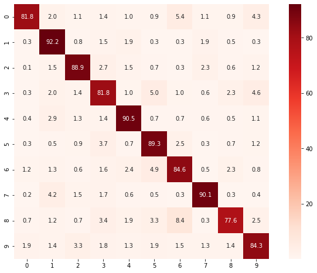

```python
from sklearn.metrics import confusion_matrix
# Set the figure size
plt.figure(figsize=(12, 8))

# Calculate the confusion matrix
cm = confusion_matrix(y_true=np.argmax(y_test, axis=1), y_pred=flat_array)

# Normalize the confusion matrix
cm = cm.astype('float') / cm.sum(axis=1)[:, np.newaxis] * 100.0

# Visualize the confusion matrix
sns.heatmap(cm, annot=True, cmap='Reds', fmt='.1f', square=True);
```

##### Analyzing incorrectly and correctly classified images

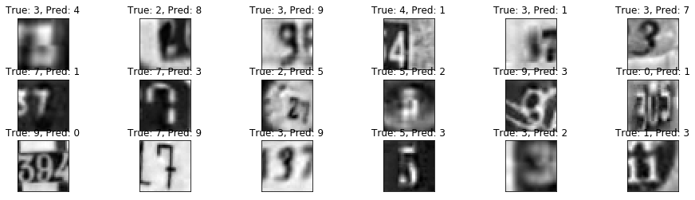

```python
incorrect = flat_array != np.argmax(y_test, axis=1)

images = X_test[incorrect]
cls_true = y_test[incorrect]
cls_pred = flat_array[incorrect]

plot_images(images, 3, 6, cls_true, cls_pred);
```

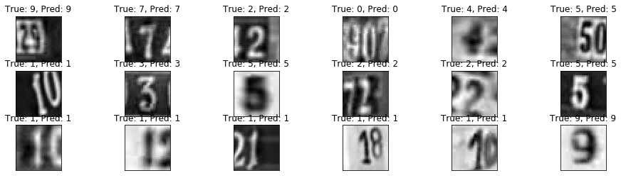

```python
correct = np.invert(incorrect)

images = X_test[correct]
cls_true = y_test[correct]
cls_pred = flat_array[correct]


plot_images(images, 3, 6, cls_true, cls_pred);
```

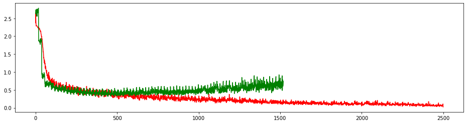

```python
import matplotlib.pyplot as plt
plt.plot(train_loss ,'r')
plt.plot(valid_loss, 'g')
```

## Modeling using Keras framework

#### Modeling on greyscale images using keras

```python
from __future__ import absolute_import
from __future__ import print_function

# Ignore warnings :
import warnings
warnings.filterwarnings('ignore')

import os
import itertools
import numpy as np
import scipy.io
import matplotlib.pyplot as plt
from scipy.io import loadmat

import keras
from keras.models import Sequential
from keras.utils import np_utils
from keras.layers import Dense, Dropout, Activation, BatchNormalization,Flatten
from keras.layers.convolutional import Convolution2D, MaxPooling2D
from keras.optimizers import SGD, Adadelta, Adagrad
from keras.utils import to_categorical

from sklearn import datasets
from sklearn.model_selection import train_test_split
from sklearn.model_selection import GridSearchCV
```

```python
# Open the file as readonly
h5f = h5py.File('SVHN_grey.h5', 'r')

# Load the training, test and validation set
X_train = h5f['X_train'][:]
y_train = h5f['y_train'][:]
X_test = h5f['X_test'][:]
y_test = h5f['y_test'][:]
X_val = h5f['X_val'][:]
y_val = h5f['y_val'][:]

# Close this file
h5f.close()

print('Training set', X_train.shape, y_train.shape)
print('Validation set', X_val.shape, y_val.shape)
print('Test set', X_test.shape, y_test.shape)
```

```
Training set (63733, 32, 32, 1) (63733, 10)
Validation set (9524, 32, 32, 1) (9524, 10)
Test set (26032, 32, 32, 1) (26032, 10)
```

```python
# Find the unique numbers from the train labels
classes = np.unique(y_train)
nClasses = len(classes)
print('Total number of outputs : ', nClasses)
print('Output classes : ', classes)
```

```
Total number of outputs :  2
Output classes :  [0. 1.]
```

```python
batch_size = 128
nb_classes = 10
nb_epoch = 20

model = Sequential()
model.add(Convolution2D(32, (3, 3), activation='relu', input_shape=(32, 32, 1)))
model.add(MaxPooling2D((2, 2)))
model.add(Dropout(0.25))
model.add(Convolution2D(64, (3, 3), activation='relu'))
model.add(MaxPooling2D((2, 2)))
model.add(Dropout(0.25))
model.add(Convolution2D(64, (3, 3), activation='relu'))
model.add(Flatten())
model.add(Dense(64, activation='relu'))
model.add(Dropout(0.5))
model.add(Dense(10,activation='softmax'))


model.compile(loss='categorical_crossentropy', optimizer='adam',metrics=['accuracy'])
```

```python
grey_model=model.fit(X_train, y_train, batch_size=batch_size, nb_epoch=nb_epoch, verbose=1, validation_data=(X_val,y_val))
```

```
Train on 63733 samples, validate on 9524 samples
```

```python
score = model.evaluate(X_test, y_test, verbose = 1)
print('loss:', score[0])
print('accuracy:', score[1])
```

```
loss: 0.28773880639120925
accuracy: 0.9219038106945298
```

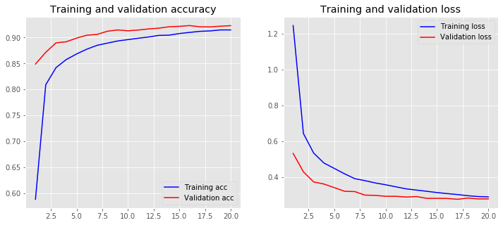

```python
import matplotlib.pyplot as plt
plt.style.use('ggplot')

def plot_history(history):
    acc = history.history['acc']
    val_acc = history.history['val_acc']
    loss = history.history['loss']
    val_loss = history.history['val_loss']
    x = range(1, len(acc) + 1)

    plt.figure(figsize=(12, 5))
    plt.subplot(1, 2, 1)
    plt.plot(x, acc, 'b', label='Training acc')
    plt.plot(x, val_acc, 'r', label='Validation acc')
    plt.title('Training and validation accuracy')
    plt.legend()
    plt.subplot(1, 2, 2)
    plt.plot(x, loss, 'b', label='Training loss')
    plt.plot(x, val_loss, 'r', label='Validation loss')
    plt.title('Training and validation loss')
    plt.legend()
    plt.show()


plot_history(grey_model)
```

#### Modeling on non greyscale images using keras

```python
## Import Packages
import tensorflow
import warnings
warnings.filterwarnings('ignore')
from keras.layers.normalization import BatchNormalization
from keras.layers import Dense, Dropout, Activation, BatchNormalization,Flatten
from keras.layers.convolutional import Convolution2D, MaxPooling2D
from keras.models import Sequential
from keras.layers import Dense, Dropout, Activation
from keras.models import load_model
from sklearn.metrics import accuracy_score
import keras
import tempfile
import seaborn as sns
import scipy
from scipy.io import loadmat
import os
import numpy as np
import pandas as pd
## View sample data
import matplotlib.pyplot as plt
import matplotlib.image as mpimg
from scipy.ndimage.filters import correlate, convolve

%matplotlib inline
```

```python
# Read the Image Data
train_data = loadmat('train_32x32.mat')
test_data = loadmat('test_32x32.mat')

# X are the pixels of the images and y are the corresponding labels.
def load_data(path):
    """ Helper function for loading a MAT-File"""
    data = loadmat(path)
    return data['X'], data['y']

X_train, y_train = load_data('train_32x32.mat')
X_test, y_test = load_data('test_32x32.mat')

print("Training Set", X_train.shape, y_train.shape)
print("Test Set", X_test.shape, y_test.shape)
```

```
Training Set (32, 32, 3, 73257) (73257, 1)
Test Set (32, 32, 3, 26032) (26032, 1)
```

```python
# Transpose the image arrays, we are transforming the input data so that each instance of
#data represents pixels values of each image in all of three channels(RGB)

X_train, y_train = X_train.transpose((3,0,1,2)), y_train[:,0]
X_test, y_test = X_test.transpose((3,0,1,2)), y_test[:,0]

print("Training Set", X_train.shape)
print("Test Set", X_test.shape)
print('')

# Calculate the total number of images
num_images = X_train.shape[0] + X_test.shape[0]

print("Total Number of Images", num_images)
```

```
Training Set (73257, 32, 32, 3)
Test Set (26032, 32, 32, 3)

Total Number of Images 99289
```

```python
#Converting Label 10 -> 0
y_train[y_train == 10] = 0
y_test[y_test == 10] = 0
```

```python
print(np.unique(y_train))
```

```
[0 1 2 3 4 5 6 7 8 9]
```

```python
# Splitting to 13% in Val Set
X_train, X_val, y_train, y_val = train_test_split(X_train, y_train, test_size=0.13, random_state=7, stratify = y_train)
```

```python
# Data in each Set
y_train.shape, y_val.shape, y_test.shape
```

```
((63733,), (9524,), (26032,))
```

```python
# Calculate the mean on the training data
train_mean = np.mean(X_train, axis=0)

# Calculate the std on the training data
train_std = np.std(X_train, axis=0)

# Subtract it equally from all splits
train_norm = (X_train - train_mean) / train_std
test_norm = (X_test - train_mean)  / train_std
val_norm = (X_val - train_mean) / train_std
```

```python
from sklearn.preprocessing import OneHotEncoder

# Fit the OneHotEncoder
enc = OneHotEncoder().fit(y_train.reshape(-1, 1))

# Transform the label values to a one-hot-encoding scheme
y_train = enc.transform(y_train.reshape(-1, 1)).toarray()
y_test = enc.transform(y_test.reshape(-1, 1)).toarray()
y_val = enc.transform(y_val.reshape(-1, 1)).toarray()

print("Training set", y_train.shape)
print("Validation set", y_val.shape)
print("Test set", y_test.shape)
```

```
Training set (63733, 10)
Validation set (9524, 10)
Test set (26032, 10)
```

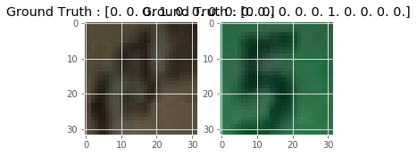

```python
plt.figure(figsize=[5,5])

# Display the first image in training data
plt.subplot(121)
plt.imshow(X_train[0,:,:])
plt.title("Ground Truth : {}".format(y_train[0]))

# Display the first image in testing data
plt.subplot(122)
plt.imshow(X_test[0,:,:])
plt.title("Ground Truth : {}".format(y_test[0]))
```

```python
# We will use 3 filters,3 drop out with
# Max pooling of 2,2 pixel i.e. taking the max from 2 col & 2 rows
# 2 layers of weights i.e. Dense Layer

batch_size = 128
nb_classes = 10
nb_epoch = 20

model = Sequential()
model.add(Convolution2D(32, (3, 3), activation='relu', input_shape=(32, 32, 3)))
model.add(MaxPooling2D((2, 2)))
model.add(Dropout(0.25))
model.add(Convolution2D(64, (3, 3), activation='relu'))
model.add(MaxPooling2D((2, 2)))
model.add(Dropout(0.25))
model.add(Convolution2D(64, (3, 3), activation='relu'))
model.add(Flatten())
model.add(Dense(64, activation='relu'))
model.add(Dropout(0.5))
model.add(Dense(10,activation='softmax'))


model.compile(loss='categorical_crossentropy', optimizer='adam',metrics=['accuracy'])
```

```python
model.summary()
```

```
_________________________________________________________________
Layer (type)                 Output Shape              Param #
=================================================================
conv2d_84 (Conv2D)           (None, 30, 30, 32)        896
_________________________________________________________________
max_pooling2d_55 (MaxPooling (None, 15, 15, 32)        0
_________________________________________________________________
dropout_82 (Dropout)         (None, 15, 15, 32)        0
_________________________________________________________________
conv2d_85 (Conv2D)           (None, 13, 13, 64)        18496
_________________________________________________________________
max_pooling2d_56 (MaxPooling (None, 6, 6, 64)          0
_________________________________________________________________
dropout_83 (Dropout)         (None, 6, 6, 64)          0
_________________________________________________________________
conv2d_86 (Conv2D)           (None, 4, 4, 64)          36928
_________________________________________________________________
flatten_28 (Flatten)         (None, 1024)              0
_________________________________________________________________
dense_55 (Dense)             (None, 64)                65600
_________________________________________________________________
dropout_84 (Dropout)         (None, 64)                0
_________________________________________________________________
dense_56 (Dense)             (None, 10)                650
=================================================================
Total params: 122,570
Trainable params: 122,570
Non-trainable params: 0
_________________________________________________________________
```

```python
## Train the data using 20 epochs and batch size 128
train_model=model.fit(X_train, y_train, batch_size=batch_size, nb_epoch=nb_epoch, verbose=1, validation_data=(X_val, y_val))
```

```
Train on 63733 samples, validate on 9524 samples
```

```python
scores = model.evaluate(X_test, y_test, batch_size = 128, verbose = 0)
print(' loss:', scores[0])
print('Test accuracy:', scores[1])
```

[output not shown]

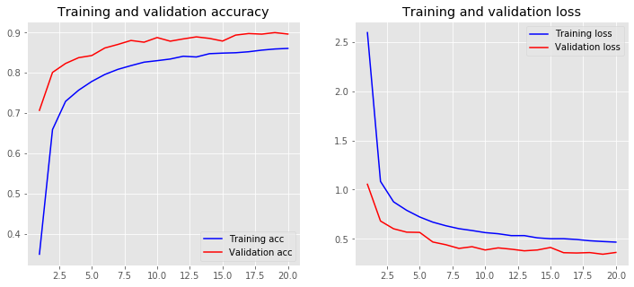

```python
import matplotlib.pyplot as plt
plt.style.use('ggplot')

def plot_history(history):
    acc = history.history['acc']
    val_acc = history.history['val_acc']
    loss = history.history['loss']
    val_loss = history.history['val_loss']
    x = range(1, len(acc) + 1)

    plt.figure(figsize=(12, 5))
    plt.subplot(1, 2, 1)
    plt.plot(x, acc, 'b', label='Training acc')
    plt.plot(x, val_acc, 'r', label='Validation acc')
    plt.title('Training and validation accuracy')
    plt.legend()
    plt.subplot(1, 2, 2)
    plt.plot(x, loss, 'b', label='Training loss')
    plt.plot(x, val_loss, 'r', label='Validation loss')
    plt.title('Training and validation loss')
    plt.legend()
    plt.show()


plot_history(train_model)
```

```python
## Predict the classes given to model, we do not want probabilities for each class.
class_prediction =model.predict_classes(X_test,batch_size=128,verbose=True)
```

```python
Predicted_class_label=class_prediction
```

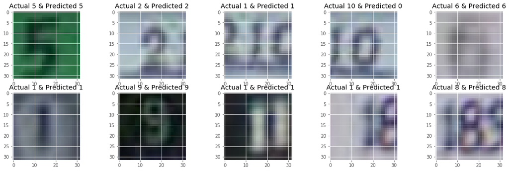

```python
## Visualize the Image with Actual Label and Predicted Label using imshow function from Matplotlib
y = test_data['y'][:,0]

fig = plt.figure(figsize=(20,6))
axes = fig.subplots(nrows=2, ncols=5)

axes[0,0].set_title('Actual {} & Predicted {}'.format(y[0],Predicted_class_label[0]))  ## Label
axes[0,0].imshow(X_test[0]) ## Image

axes[0,1].set_title('Actual {} & Predicted {}'.format(y[1],Predicted_class_label[1]))
axes[0,1].imshow(X_test[1])

axes[0,2].set_title('Actual {} & Predicted {}'.format(y[2],Predicted_class_label[2]))
axes[0,2].imshow(X_test[2])

axes[0,3].set_title('Actual {} & Predicted {}'.format(y[3],Predicted_class_label[3]))
axes[0,3].imshow(X_test[3])

axes[0,4].set_title('Actual {} & Predicted {}'.format(y[4],Predicted_class_label[4]))
axes[0,4].imshow(X_test[4])

axes[1,0].set_title('Actual {} & Predicted {}'.format(y[5],Predicted_class_label[5]))
axes[1,0].imshow(X_test[5])

axes[1,1].set_title('Actual {} & Predicted {}'.format(y[6],Predicted_class_label[6]))
axes[1,1].imshow(X_test[6])

axes[1,2].set_title('Actual {} & Predicted {}'.format(y[7],Predicted_class_label[7]))
axes[1,2].imshow(X_test[7])

axes[1,3].set_title('Actual {} & Predicted {}'.format(y[8],Predicted_class_label[8]))
axes[1,3].imshow(X_test[8])

axes[1,4].set_title('Actual {} & Predicted {}'.format(y[9],Predicted_class_label[9]))
axes[1,4].imshow(X_test[9])
plt.show()
```

```python
model.save('street_view_house_numbers_model.h5')
```

#### Batch normalization

```python
# We will use 3 filters,3 drop out with
# Batch Normalization to normalize the pixels in each filter so that model each of itself more independently of other layers
# Max pooling of 2,2 pixel i.e. taking the max from 2 col & 2 rows
# 2 layers of weights i.e. Dense Layer
batch_size = 128
nb_classes = 10
nb_epoch = 20

model = Sequential()
model.add(Convolution2D(32, (3, 3), activation='relu', input_shape=(32, 32, 3)))
model.add(BatchNormalization())
model.add(MaxPooling2D((2, 2)))
model.add(Dropout(0.25))
model.add(Convolution2D(64, (3, 3), activation='relu'))
model.add(BatchNormalization())
model.add(MaxPooling2D((2, 2)))
model.add(Dropout(0.25))
model.add(Convolution2D(64, (3, 3), activation='relu'))
model.add(Flatten())
model.add(BatchNormalization())
model.add(Dense(64, activation='relu'))
model.add(BatchNormalization())
model.add(Dropout(0.5))
model.add(Dense(10,activation='softmax'))


model.compile(loss='categorical_crossentropy', optimizer='adam',metrics=['accuracy'])
```

```python
## Train the data using 20 epochs and batch size 128
batch_model = model.fit(X_train, y_train,batch_size=128, epochs=20, verbose=1,validation_data=(X_val, y_val))
```

```
Train on 63733 samples, validate on 9524 samples
```

```python
scores_batch = model.evaluate(X_test, y_test, batch_size = 128, verbose = 0)
print('loss:', scores_batch[0])
print('Test accuracy:', scores_batch[1])
```

```
loss: 0.3058530417463863
Test accuracy: 0.909764904696002
```

```python
## Predict the classes given to model, we do not want probabilities for each class.
class_prediction =model.predict_classes(X_test,batch_size=128,verbose=True)
```

```python
Predicted_class_label=class_prediction
```

```python
## Save the batch model so that we can reused this instead of running train again.
model.save('svhn_new_normal.h5')
```

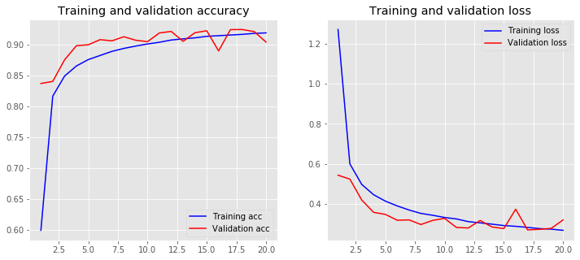

```python
import matplotlib.pyplot as plt
plt.style.use('ggplot')

def plot_history(history):
    acc = history.history['acc']
    val_acc = history.history['val_acc']
    loss = history.history['loss']
    val_loss = history.history['val_loss']
    x = range(1, len(acc) + 1)

    plt.figure(figsize=(12, 5))
    plt.subplot(1, 2, 1)
    plt.plot(x, acc, 'b', label='Training acc')
    plt.plot(x, val_acc, 'r', label='Validation acc')
    plt.title('Training and validation accuracy')
    plt.legend()
    plt.subplot(1, 2, 2)
    plt.plot(x, loss, 'b', label='Training loss')
    plt.plot(x, val_loss, 'r', label='Validation loss')
    plt.title('Training and validation loss')
    plt.legend()
    plt.show()


plot_history(batch_model)
```

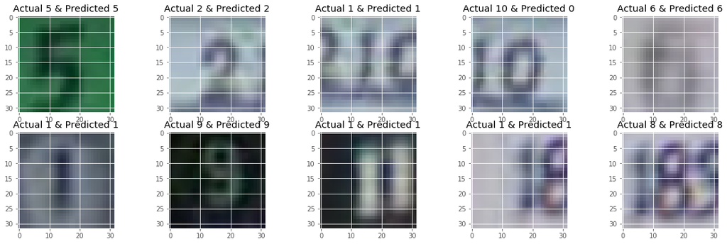

```python
## Visualize the Image with Actual Label and Predicted Label using imshow function from Matplotlib
y = test_data['y'][:,0]

fig = plt.figure(figsize=(20,6))
axes = fig.subplots(nrows=2, ncols=5)

axes[0,0].set_title('Actual {} & Predicted {}'.format(y[0],Predicted_class_label[0]))  ## Label
axes[0,0].imshow(X_test[0]) ## Image

axes[0,1].set_title('Actual {} & Predicted {}'.format(y[1],Predicted_class_label[1]))
axes[0,1].imshow(X_test[1])

axes[0,2].set_title('Actual {} & Predicted {}'.format(y[2],Predicted_class_label[2]))
axes[0,2].imshow(X_test[2])

axes[0,3].set_title('Actual {} & Predicted {}'.format(y[3],Predicted_class_label[3]))
axes[0,3].imshow(X_test[3])

axes[0,4].set_title('Actual {} & Predicted {}'.format(y[4],Predicted_class_label[4]))
axes[0,4].imshow(X_test[4])

axes[1,0].set_title('Actual {} & Predicted {}'.format(y[5],Predicted_class_label[5]))
axes[1,0].imshow(X_test[5])

axes[1,1].set_title('Actual {} & Predicted {}'.format(y[6],Predicted_class_label[6]))
axes[1,1].imshow(X_test[6])

axes[1,2].set_title('Actual {} & Predicted {}'.format(y[7],Predicted_class_label[7]))
axes[1,2].imshow(X_test[7])

axes[1,3].set_title('Actual {} & Predicted {}'.format(y[8],Predicted_class_label[8]))
axes[1,3].imshow(X_test[8])

axes[1,4].set_title('Actual {} & Predicted {}'.format(y[9],Predicted_class_label[9]))
axes[1,4].imshow(X_test[9])
plt.show()
```

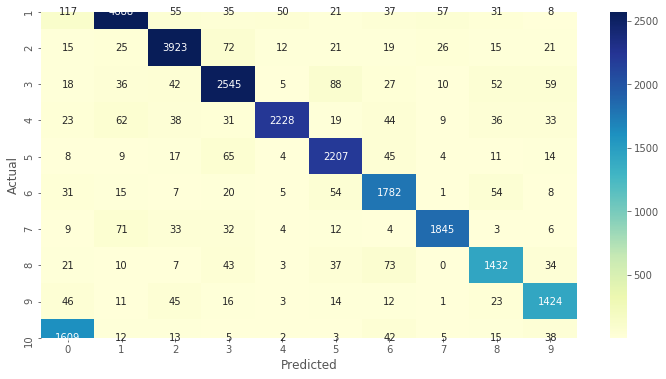

```python
## Visualizing the confusion matrix: This will help in identifying which class was misclassified minimum or maximum times

plt.figure(figsize = (12,6))
sns.heatmap(pd.crosstab(y,Predicted_class_label,rownames=['Actual'],colnames=['Predicted']), annot=True,  fmt="d",cmap="YlGnBu",robust =True)
plt.show()
```

Classification model

```python
import matplotlib.pyplot as plt
import numpy as np

from sklearn.metrics import classification_report, confusion_matrix, accuracy_score
from sklearn.model_selection import cross_val_score
from sklearn.decomposition import PCA

from sklearn import svm
from sklearn.ensemble import RandomForestClassifier
from sklearn.neighbors import KNeighborsClassifier
from sklearn.linear_model import LogisticRegression
```

```python
# X are the pixels of the images and y are the corresponding labels.
def load_data(path):
    """ Helper function for loading a MAT-File"""
    data = loadmat(path)
    return data['X'], data['y']

X_train, y_train = load_data('train_32x32.mat')
X_test, y_test = load_data('test_32x32.mat')

print("Training Set", X_train.shape, y_train.shape)
print("Test Set", X_test.shape, y_test.shape)
```

```
Training Set (32, 32, 3, 73257) (73257, 1)
Test Set (32, 32, 3, 26032) (26032, 1)
```

```python
# Transpose the image arrays, we are transforming the input data so that each instance of
#data represents pixels values of each image in all of three channels(RGB)

X_train, y_train = X_train.transpose((3,0,1,2)), y_train[:,0]
X_test, y_test = X_test.transpose((3,0,1,2)), y_test[:,0]

print("Training Set", X_train.shape)
print("Test Set", X_test.shape)
print('')

# Calculate the total number of images
num_images = X_train.shape[0] + X_test.shape[0]

print("Total Number of Images", num_images)
```

```
Training Set (73257, 32, 32, 3)
Test Set (26032, 32, 32, 3)

Total Number of Images 99289
```

```python
x_train = X_train.reshape(X_train.shape[0],-1)
x_test = X_test.reshape(X_test.shape[0], -1)
```

```python
pca = PCA()
pca.fit_transform(x_train)
```

```
array([[-2.85185876e+03, -3.04061873e+02, -3.40748617e+02, ...,
         1.93664053e-02,  7.08686286e-01, -4.12148060e-01],
       [-2.31710646e+03, -4.54449011e+02, -5.67618848e+02, ...,
         3.92243245e-02, -4.64754961e-02, -5.29372807e-02],
       [ 3.85752887e+03, -4.43666525e+02,  2.12171126e+03, ...,
        -2.36214248e-01,  1.91755709e-01,  2.19721047e-01],
       ...,
       [ 4.02785488e+03, -1.32823327e+03,  2.36196656e+02, ...,
        -3.27279066e-01, -5.56027663e-01, -4.29651612e-01],
       [ 5.35876774e+03, -1.78005523e+02,  2.37036963e+02, ...,
        -1.84068395e-01, -3.08189621e-01, -1.08309846e-01],
       [ 5.34434415e+03,  4.24293462e+02,  3.20580997e+02, ...,
         1.20913046e-01,  8.09809575e-02, -1.49830313e-01]])
```

```python
pca.explained_variance_.shape
```

```
(3072,)
```

```python
# Calculating optimal k to have 95% (say) variance
k = 0
total = sum(pca.explained_variance_)
current_sum = 0

while(current_sum / total < 0.99):
    current_sum += pca.explained_variance_[k]
    k += 1
k
```

```
173
```

```python
## Applying PCA with k calcuated above
pca = PCA(n_components=k, whiten=True)
x_train_pca = pca.fit_transform(x_train)
x_test_pca = pca.transform(x_test)
```

Random forest classifier

```python
# Training
rf = RandomForestClassifier()
rf.fit(x_train_pca, y_train)
# Prediction
y_pred_rf = rf.predict(x_test_pca)
random_forest_score = accuracy_score(y_test, y_pred_rf)
random_forest_score
```

[output not shown]

k-nearest neighbors algorithm

```python
#Training
knn = KNeighborsClassifier()
knn.fit(x_train_pca, y_train)
# Prediction
y_pred_knn = knn.predict(x_test_pca)
knn_score = accuracy_score(y_test, y_pred_knn)
knn_score
```

```
0.4840580823601721
```

Logistic regression

```python
#Training
lr = LogisticRegression()
lr.fit(x_train_pca, y_train)
# Prediction
y_pred_lr = lr.predict(x_test_pca)
logistic_regression_score = accuracy_score(y_test, y_pred_lr)
logistic_regression_score
```

```
0.24627381684081132
```

```python
print("RandomForestClassifier : ", random_forest_score)
print("K Nearest Neighbors : ", knn_score)
print("Logistic Regression : ", logistic_regression_score)
```

```
RandomForestClassifier :  0.5112169637369391
K Nearest Neighbors :  0.4840580823601721
Logistic Regression :  0.24627381684081132
```